# Comparison of 4 student groups identified through regularity of study clustering model

Load cluster assignments

```r
cluster.assignments <- read.csv("Intermediate_results/regularity_of_study/regularity_based_clusters.csv")
```

# Cluster comparison w.r.t. the students’ exam scores

Load exam scores

```r
exam.scores <- read.csv(file = "Intermediate_results/exam_scores_with_student_ids.csv")
exam.scores <- exam.scores %>% select(-EMAIL)
str(exam.scores)
```

```
'data.frame':   491 obs. of  3 variables:
 $ USER_ID  : int  NA 1446 961 866 937 734 1077 953 852 932 ...
 $ SC_MT_TOT: int  6 11 13 15 17 12 13 15 8 16 ...
 $ SC_FE_TOT: int  0 15 15 24 27 11 11 35 12 33 ...
```

Merge cluster data with exam scores

```r
stud.clust <- merge(x = cluster.assignments %>% select(-cl3),
                    y = exam.scores,
                    by.x = 'user_id', by.y = 'USER_ID',
                    all.x = T, all.y = F)
summary(stud.clust %>% select(SC_MT_TOT, SC_FE_TOT))
```

```
   SC_MT_TOT       SC_FE_TOT
 Min.   : 0.00   Min.   : 0.00
 1st Qu.:10.00   1st Qu.:12.00
 Median :13.00   Median :18.00
 Mean   :12.89   Mean   :19.43
 3rd Qu.:16.00   3rd Qu.:27.00
 Max.   :20.00   Max.   :40.00
```

Compute the summary statistics for the students’ exam scores

```r
cl4.stats <- summary.stats(stud.clust %>% select(SC_MT_TOT, SC_FE_TOT), stud.clust$cl4, 4)
kable(x = cl4.stats)
```

| attributes | Median; (Q1, Q3) | Median; (Q1, Q3) | Median; (Q1, Q3) | Median; (Q1, Q3) |
| --- | --- | --- | --- | --- |
| cluster | 1 | 2 | 3 | 4 |
| freq | 170 | 155 | 56 | 96 |
| SC_MT_TOT | 15; (12, 17) | 12; (9, 15) | 10; (7, 12.25) | 13.5; (11, 16.25) |
| SC_FE_TOT | 24; (16, 32) | 15; (11, 22) | 11; (3.75, 17) | 20; (14, 29.25) |

### Comparison based on *final* exam scores

```r
kruskal.test(stud.clust$SC_FE_TOT ~ stud.clust$cl4)
```

```
    Kruskal-Wallis rank sum test

data:  stud.clust$SC_FE_TOT by stud.clust$cl4
Kruskal-Wallis chi-squared = 80.217, df = 3, p-value < 2.2e-16
```

Pair-wise comparisons with Mann-Whitney U Test

```r
cl4.df <- stud.clust
colnames(cl4.df)[2] <- "class"
kable(pairwise.fexam.compare(4, 6, cl4.df))
```

|  | c1 | c2 | Z | p | r | significant | alpha |
| --- | --- | --- | --- | --- | --- | --- | --- |
| 1 | 1 | 2 | 5.9746 | 0.000000 | 0.3314 | YES | 0.0083333 |
| 2 | 1 | 3 | 7.6371 | 0.000000 | 0.5080 | YES | 0.0166667 |
| 6 | 3 | 4 | -6.1010 | 0.000000 | 0.4949 | YES | 0.0250000 |
| 4 | 2 | 3 | 4.1907 | 0.000021 | 0.2885 | YES | 0.0333333 |
| 5 | 2 | 4 | -3.6103 | 0.000279 | 0.2279 | YES | 0.0416667 |
| 3 | 1 | 4 | 1.8150 | 0.069536 | 0.1113 | NO | 0.0500000 |

Except for the cluster pair 1-4, all other cluster pairs are significantly different w.r.t. the *final exam* score.

### Cluster comparison based on *midterm* exam scores

```r
kruskal.test(stud.clust$SC_MT_TOT ~ stud.clust$cl4)
```

```
    Kruskal-Wallis rank sum test

data:  stud.clust$SC_MT_TOT by stud.clust$cl4
Kruskal-Wallis chi-squared = 64.372, df = 3, p-value = 6.835e-14
```

```r
kable(pairwise.mtxam.compare(4, 6, cl4.df))
```

|  | c1 | c2 | Z | p | r | significant | alpha |
| --- | --- | --- | --- | --- | --- | --- | --- |
| 1 | 1 | 2 | 5.5388 | 0.000000 | 0.3072 | YES | 0.0083333 |
| 2 | 1 | 3 | 6.8792 | 0.000000 | 0.4576 | YES | 0.0166667 |
| 6 | 3 | 4 | -5.3004 | 0.000000 | 0.4299 | YES | 0.0250000 |
| 4 | 2 | 3 | 3.4885 | 0.000430 | 0.2402 | YES | 0.0333333 |
| 5 | 2 | 4 | -2.9288 | 0.003291 | 0.1849 | YES | 0.0416667 |
| 3 | 1 | 4 | 1.9816 | 0.047436 | 0.1215 | YES | 0.0500000 |

All cluster pairs are significantly different w.r.t. the *midterm exam* score.

# Cluster comparison w.r.t. some indicators of study habits

Compare the clusters of the 4 cluster model with respect to the following variables:

- *week_prop_sd* - standard deviation (SD) of weekly session proportions (weeks 6 and 13 are excluded)
- *weekday_prop_sd* - SD of weekday session proportions (weeks 6 and 13 are excluded)
- *ses_timegap_mad* - Median Absolute Deviation (MAD) of the time gap (measured in minutes) between consecutive study sessions
- *on_topic_prop* - proportions of on-topic or ‘preparation’ sessions; computed as the ratio of the number of sessions with the main topic being the week’s topic and the total number of sessions of the given student (weeks 6 and 13 are excluded)
- *on_topic_prop_sd* - SD of on-topic proportions computed at the weekly level (weeks 6 and 13 are excluded)
- *last_min_prop* - the proportion of on-topic (‘preparation’) sessions done in 24h before a week’s lecture (weeks 6 and 13 are excluded)
- *last_min_prop_sd* - SD in the weekly proportions of last minute preparation sessions

Load the indicators

```r
indicators <- read.csv("Intermediate_results/regularity_of_study/regularity_indicators.csv")
# keep only the above listed indicators
indicators <- indicators %>%
  select(user_id, week_prop_sd, weekday_prop_sd, ses_timegap_mad,
         on_topic_prop, on_topic_prop_sd, last_min_prop, last_min_prop_sd)
# merge indicators with cluster assignments
clust.data <- merge(x = indicators, y = cluster.assignments[,-2],
                    by = 'user_id', all.x = FALSE, all.y = TRUE)
```

Compute cluster-level summary statistics for the selected indicators

```r
clust.stats <- summary.stats(clust.data %>% select(-c(user_id, cl4)), clust.data$cl4, 4)
kable(x = clust.stats)
```

| attributes | Median; (Q1, Q3) | Median; (Q1, Q3) | Median; (Q1, Q3) | Median; (Q1, Q3) |
| --- | --- | --- | --- | --- |
| cluster | 1 | 2 | 3 | 4 |
| freq | 170 | 155 | 56 | 96 |
| week_prop_sd | 0.04; (0.03, 0.05) | 0.05; (0.05, 0.07) | 0.07; (0.06, 0.1) | 0.05; (0.04, 0.06) |
| weekday_prop_sd | 0.11; (0.09, 0.13) | 0.15; (0.13, 0.17) | 0.21; (0.17, 0.23) | 0.14; (0.12, 0.16) |
| ses_timegap_mad | 466.3; (263.79, 841.14) | 877.17; (451.17, 1501.57) | 1194.41; (364.78, 2571.66) | 614.53; (307.55, 913.16) |
| on_topic_prop | 0.47; (0.38, 0.62) | 0.42; (0.34, 0.53) | 0.4; (0.25, 0.5) | 0.43; (0.33, 0.53) |
| on_topic_prop_sd | 0.26; (0.2, 0.31) | 0.32; (0.25, 0.38) | 0.38; (0.25, 0.45) | 0.28; (0.24, 0.34) |
| last_min_prop | 0.11; (0.05, 0.17) | 0.11; (0.05, 0.18) | 0.08; (0, 0.21) | 0.12; (0.04, 0.19) |
| last_min_prop_sd | 0.28; (0.18, 0.37) | 0.36; (0.23, 0.45) | 0.41; (0.03, 0.49) | 0.37; (0.24, 0.43) |

Check if there is a stat. significant difference among the clusters w.r.t. the selected indicators

```r
apply(clust.data[,-c(1,9)], 2, function(x) kruskal.test(x ~ clust.data$cl4))
```

```
$week_prop_sd

    Kruskal-Wallis rank sum test

data:  x by clust.data$cl4
Kruskal-Wallis chi-squared = 93.443, df = 3, p-value < 2.2e-16


$weekday_prop_sd

    Kruskal-Wallis rank sum test

data:  x by clust.data$cl4
Kruskal-Wallis chi-squared = 172.36, df = 3, p-value < 2.2e-16


$ses_timegap_mad

    Kruskal-Wallis rank sum test

data:  x by clust.data$cl4
Kruskal-Wallis chi-squared = 51.445, df = 3, p-value = 3.933e-11


$on_topic_prop

    Kruskal-Wallis rank sum test

data:  x by clust.data$cl4
Kruskal-Wallis chi-squared = 12.517, df = 3, p-value = 0.005805


$on_topic_prop_sd

    Kruskal-Wallis rank sum test

data:  x by clust.data$cl4
Kruskal-Wallis chi-squared = 53.794, df = 3, p-value = 1.241e-11


$last_min_prop

    Kruskal-Wallis rank sum test

data:  x by clust.data$cl4
Kruskal-Wallis chi-squared = 2.083, df = 3, p-value = 0.5554


$last_min_prop_sd

    Kruskal-Wallis rank sum test

data:  x by clust.data$cl4
Kruskal-Wallis chi-squared = 22.006, df = 3, p-value = 6.506e-05
```

Significant difference is detected for all the indicators except for the ‘last_min_prop’ indicator

### Pair-wise comparisons of clusters with Mann-Whitney U Test

```r
pairwise.compare <- function(indicator, clusters, cl1, cl2) {
  indicator.cl1 <- indicator[clusters == cl1]
  indicator.cl2 <- indicator[clusters == cl2]
  do.Mann.Whitney.test(indicator.cl1, indicator.cl2, cl1, cl2)
}
pairwise.compare.clusters <- function(indicator, clusters, ncompare) {
  nclust <- length(unique(clusters))
  comparison <- matrix(nrow = ncompare, ncol = 5, byrow = T)
  k <- 1
  for(i in 1:(nclust-1)) {
    for(j in (i+1):nclust) {
        comparison[k,] <- c(i, j, pairwise.compare(indicator, clusters, i, j))
        k <- k+1
    }
  }
  comparison.df <- as.data.frame(comparison)
  colnames(comparison.df) <- c('c1', 'c2', 'Z', 'p', 'r')
  comparison.df <- apply.FDR.correction(comparison.df)
  comparison.df
}
```

#### Comparison based on the *week_prop_sd* indicator

```r
week_prop_sd_compare <- pairwise.compare.clusters(clust.data$week_prop_sd, clust.data$cl4, 6)
kable(week_prop_sd_compare)
```

|  | c1 | c2 | Z | p | r | significant | alpha |
| --- | --- | --- | --- | --- | --- | --- | --- |
| 1 | 1 | 2 | -6.3812 | 0.000000 | 0.3540 | YES | 0.0083333 |
| 2 | 1 | 3 | -8.2995 | 0.000000 | 0.5521 | YES | 0.0166667 |
| 4 | 2 | 3 | -5.1929 | 0.000000 | 0.3575 | YES | 0.0250000 |
| 6 | 3 | 4 | 6.2546 | 0.000000 | 0.5073 | YES | 0.0333333 |
| 5 | 2 | 4 | 2.9481 | 0.003089 | 0.1861 | YES | 0.0416667 |
| 3 | 1 | 4 | -2.8145 | 0.004759 | 0.1726 | YES | 0.0500000 |

All cluster pairs are significantly different w.r.t. the *week_prop_sd* indicator

#### Comparison based on the *weekday_prop_sd* indicator

```r
weekday_prop_sd_compare <- pairwise.compare.clusters(clust.data$weekday_prop_sd, clust.data$cl4, 6)
kable(weekday_prop_sd_compare)
```

|  | c1 | c2 | Z | p | r | significant | alpha |
| --- | --- | --- | --- | --- | --- | --- | --- |
| 1 | 1 | 2 | -10.2739 | 0.0000 | 0.5699 | YES | 0.0083333 |
| 2 | 1 | 3 | -9.6143 | 0.0000 | 0.6395 | YES | 0.0166667 |
| 3 | 1 | 4 | -6.6297 | 0.0000 | 0.4065 | YES | 0.0250000 |
| 4 | 2 | 3 | -6.0624 | 0.0000 | 0.4174 | YES | 0.0333333 |
| 6 | 3 | 4 | 6.8409 | 0.0000 | 0.5549 | YES | 0.0416667 |
| 5 | 2 | 4 | 2.8390 | 0.0044 | 0.1792 | YES | 0.0500000 |

All cluster pairs are significantly different w.r.t. the *weekday_prop_sd* indicator

#### Comparison based on the *ses_timegap_mad* indicator

```r
ses_timegap_mad_compare <- pairwise.compare.clusters(clust.data$ses_timegap_mad, clust.data$cl4, 6)
kable(ses_timegap_mad_compare)
```

|  | c1 | c2 | Z | p | r | significant | alpha |
| --- | --- | --- | --- | --- | --- | --- | --- |
| 1 | 1 | 2 | -6.1590 | 0.000000 | 0.3416 | YES | 0.0083333 |
| 2 | 1 | 3 | -4.6827 | 0.000002 | 0.3115 | YES | 0.0166667 |
| 5 | 2 | 4 | 4.0823 | 0.000038 | 0.2577 | YES | 0.0250000 |
| 6 | 3 | 4 | 3.6541 | 0.000219 | 0.2964 | YES | 0.0333333 |
| 4 | 2 | 3 | -1.6724 | 0.094768 | 0.1151 | NO | 0.0416667 |
| 3 | 1 | 4 | -1.5251 | 0.127611 | 0.0935 | NO | 0.0500000 |

Except for cluster pairs 2-3 and 1-4, other cluster pairs are significantly different w.r.t. the *ses_timegap_mad* indicator

#### Comparison based on the *on_topic_prop_sd* indicator

```r
on_topic_prop_sd_compare <- pairwise.compare.clusters(clust.data$on_topic_prop_sd, clust.data$cl4, 6)
kable(on_topic_prop_sd_compare)
```

|  | c1 | c2 | Z | p | r | significant | alpha |
| --- | --- | --- | --- | --- | --- | --- | --- |
| 1 | 1 | 2 | -5.7773 | 0.000000 | 0.3205 | YES | 0.0083333 |
| 2 | 1 | 3 | -5.5390 | 0.000000 | 0.3684 | YES | 0.0166667 |
| 6 | 3 | 4 | 3.9705 | 0.000055 | 0.3221 | YES | 0.0250000 |
| 3 | 1 | 4 | -2.9298 | 0.003283 | 0.1796 | YES | 0.0333333 |
| 5 | 2 | 4 | 2.8399 | 0.004387 | 0.1793 | YES | 0.0416667 |
| 4 | 2 | 3 | -2.5083 | 0.011853 | 0.1727 | YES | 0.0500000 |

All cluster pairs are significantly different w.r.t. the *on_topic_prop_sd* indicator

#### Comparison based on the *on_topic_prop* indicator

```r
on_topic_prop_compare <- pairwise.compare.clusters(clust.data$on_topic_prop, clust.data$cl4, 6)
kable(on_topic_prop_compare)
```

|  | c1 | c2 | Z | p | r | significant | alpha |
| --- | --- | --- | --- | --- | --- | --- | --- |
| 2 | 1 | 3 | 2.9769 | 0.002751 | 0.1980 | YES | 0.0083333 |
| 1 | 1 | 2 | 2.3657 | 0.017872 | 0.1312 | NO | 0.0166667 |
| 3 | 1 | 4 | 2.3399 | 0.019120 | 0.1435 | NO | 0.0250000 |
| 4 | 2 | 3 | 1.4620 | 0.144272 | 0.1006 | NO | 0.0333333 |
| 6 | 3 | 4 | -1.2510 | 0.212023 | 0.1015 | NO | 0.0416667 |
| 5 | 2 | 4 | 0.0984 | 0.922126 | 0.0062 | NO | 0.0500000 |

Only 1-3 cluster pair significantly differ w.r.t. the *on_topic_prop* indicator

#### Comparison based on the *last_min_prop_sd* indicator

```r
last_min_prop_sd_compare <- pairwise.compare.clusters(clust.data$last_min_prop_sd, clust.data$cl4, 6)
kable(last_min_prop_sd_compare)
```

|  | c1 | c2 | Z | p | r | significant | alpha |
| --- | --- | --- | --- | --- | --- | --- | --- |
| 1 | 1 | 2 | -4.0558 | 0.000045 | 0.2250 | YES | 0.0083333 |
| 3 | 1 | 4 | -3.6120 | 0.000278 | 0.2215 | YES | 0.0166667 |
| 2 | 1 | 3 | -2.5180 | 0.011495 | 0.1675 | YES | 0.0250000 |
| 6 | 3 | 4 | 0.8759 | 0.383008 | 0.0710 | NO | 0.0333333 |
| 4 | 2 | 3 | -0.3939 | 0.695160 | 0.0271 | NO | 0.0416667 |
| 5 | 2 | 4 | 0.3470 | 0.729434 | 0.0219 | NO | 0.0500000 |

Only 3 cluster pairs - 1-2, 1-3, and 1-4 - significantly differ w.r.t. the *last_min_prop_sd* indicator

# Cluster comparison w.r.t. the daily resource use statistics

Comparison of student clusters based on some basic statistics about the different kinds of resources students used during their active days (an active day is a day when a student had at least one study session). The types of resources considered:

- video (VIDEO)
- exercises (EXE)
- multiple choie questions (MCQ)
- reading materials (RES)
- metacognitive items (METACOG)

Computed statistics:

- median_X_cnt - median number of resources of type X used during the student’s active days (X can be VIDEO, EXE, MCQ, RES, METACOG)
- mad_X_cnt - MAD (median absolute deviation) of resources of the type X used during the student’s active days
- days_X_used - number of days when resources of the type X were used
- prop_X_used - proportion of days when resources of the type X were used versus total number of the student’s active days

Weeks 6 and 13 were excluded from the computation of the above statistics, as during these weeks one can expect different than usual pattern in the resources use.

Load the resource use stats and merge with the cluster assignments:

```r
res.use.stats <- read.csv("Intermediate_results/regularity_of_study/daily_resource_use_statistics_w2-5_7-12.csv")
res.use.stats <- merge(x = res.use.stats, y = cluster.assignments %>% select(user_id, cl4),
                       by = 'user_id', all.x = F, all.y = T)
```

Compute cluster-level summary statistics for the resource use statistics

```r
clust.res.use.stats <- summary.stats(res.use.stats %>% select(-c(user_id, cl4)),
                                     res.use.stats$cl4, 4)
kable(x = clust.res.use.stats)
```

| attributes | Median; (Q1, Q3) | Median; (Q1, Q3) | Median; (Q1, Q3) | Median; (Q1, Q3) |
| --- | --- | --- | --- | --- |
| cluster | 1 | 2 | 3 | 4 |
| freq | 170 | 155 | 56 | 96 |
| median_video_cnt | 0; (0, 0) | 0; (0, 0) | 0; (0, 0) | 0; (0, 0) |
| mad_video_cnt | 0; (0, 0) | 0; (0, 0) | 0; (0, 0) | 0; (0, 0) |
| days_video_used | 12; (9.25, 16) | 4; (2, 7) | 1; (0, 2.25) | 10; (6, 12) |
| prop_video_used | 0.31; (0.24, 0.38) | 0.16; (0.09, 0.27) | 0.05; (0, 0.14) | 0.3; (0.22, 0.36) |
| median_exe_cnt | 1; (0, 4.5) | 20.5; (2, 35) | 31.5; (1, 57.5) | 7.25; (1, 25.25) |
| mad_exe_cnt | 1.48; (0, 6.67) | 30.39; (2.97, 46.7) | 34.1; (1.48, 66.53) | 10.75; (1.48, 37.06) |
| days_exe_used | 21; (18, 23) | 16; (13, 18) | 9.5; (6, 13) | 18; (16, 20) |
| prop_exe_used | 0.51; (0.47, 0.58) | 0.61; (0.52, 0.68) | 0.62; (0.5, 0.77) | 0.56; (0.51, 0.61) |
| median_mcq_cnt | 0; (0, 0) | 0; (0, 0) | 0; (0, 0) | 0; (0, 0) |
| mad_mcq_cnt | 0; (0, 0) | 0; (0, 0) | 0; (0, 0) | 0; (0, 0) |
| days_mcq_used | 12; (9, 16) | 4; (2, 7) | 1; (0, 2.25) | 9; (6, 11) |
| prop_mcq_used | 0.3; (0.22, 0.39) | 0.16; (0.1, 0.27) | 0.1; (0, 0.2) | 0.28; (0.19, 0.35) |
| median_mcog_cnt | 0; (0, 0) | 0; (0, 0) | 0; (0, 0) | 0; (0, 0) |
| mad_mcog_cnt | 0; (0, 0) | 0; (0, 0) | 0; (0, 0) | 0; (0, 0) |
| days_mcog_used | 7; (4, 12) | 3; (2, 6) | 2; (1, 3) | 5; (3, 9) |
| prop_mcog_used | 0.19; (0.1, 0.3) | 0.12; (0.07, 0.22) | 0.12; (0.06, 0.17) | 0.18; (0.09, 0.27) |
| median_res_cnt | 11; (9, 15) | 8; (6, 11.75) | 7; (5, 11) | 11; (9, 15) |
| mad_res_cnt | 10.38; (7.41, 14.83) | 7.41; (5.93, 11.86) | 4.82; (4.26, 8.34) | 10.38; (7.41, 13.34) |
| days_res_used | 40; (37, 43) | 26; (22, 28) | 16; (11, 19) | 32; (30, 35) |
| prop_res_used | 1; (1, 1) | 1; (1, 1) | 1; (1, 1) | 1; (1, 1) |

Check if there is a stat. significant difference among the clusters w.r.t. the resource use statistics

```r
apply(res.use.stats %>% select(-c(user_id, cl4)),
      2, function(x) kruskal.test(x ~ res.use.stats$cl4))
```

```
$median_video_cnt

    Kruskal-Wallis rank sum test

data:  x by res.use.stats$cl4
Kruskal-Wallis chi-squared = 1.2835, df = 3, p-value = 0.733


$mad_video_cnt

    Kruskal-Wallis rank sum test

data:  x by res.use.stats$cl4
Kruskal-Wallis chi-squared = 1.2835, df = 3, p-value = 0.733


$days_video_used

    Kruskal-Wallis rank sum test

data:  x by res.use.stats$cl4
Kruskal-Wallis chi-squared = 240.02, df = 3, p-value < 2.2e-16


$prop_video_used

    Kruskal-Wallis rank sum test

data:  x by res.use.stats$cl4
Kruskal-Wallis chi-squared = 126.76, df = 3, p-value < 2.2e-16


$median_exe_cnt

    Kruskal-Wallis rank sum test

data:  x by res.use.stats$cl4
Kruskal-Wallis chi-squared = 94.032, df = 3, p-value < 2.2e-16


```

[output cut: 103 more lines]

```

$days_res_used

    Kruskal-Wallis rank sum test

data:  x by res.use.stats$cl4
Kruskal-Wallis chi-squared = 380.45, df = 3, p-value < 2.2e-16


$prop_res_used

    Kruskal-Wallis rank sum test

data:  x by res.use.stats$cl4
Kruskal-Wallis chi-squared = 5.1655, df = 3, p-value = 0.1601
```

Stat. significant difference among the clusters is present for the following variables:

- days_video_used
- prop_video_used
- median_exe_cnt
- mad_exe_cnt
- days_exe_used
- prop_exe_used
- days_mcq_used
- prop_mcq_used
- median_mcog_cnt
- mad_mcog_cnt
- days_mcog_used
- prop_mcog_used
- median_res_cnt
- mad_res_cnt
- days_res_used

note: p values for median_mcog_cnt and mad_mcog_cnt are close to the set alpha value (0.05), so, at most one pair of clusters could be significantly different w.r.t. these variables

### Pair-wise comparisons of clusters with Mann-Whitney U Test

#### Comparison based on the *days_video_used* variable

```r
days_video_used_compare <- pairwise.compare.clusters(res.use.stats$days_video_used,
                                                     res.use.stats$cl4, 6)
kable(days_video_used_compare)
```

|  | c1 | c2 | Z | p | r | significant | alpha |
| --- | --- | --- | --- | --- | --- | --- | --- |
| 1 | 1 | 2 | 12.0085 | 0e+00 | 0.6661 | YES | 0.0083333 |
| 2 | 1 | 3 | 10.6822 | 0e+00 | 0.7106 | YES | 0.0166667 |
| 4 | 2 | 3 | 6.9428 | 0e+00 | 0.4780 | YES | 0.0250000 |
| 5 | 2 | 4 | -7.7796 | 0e+00 | 0.4910 | YES | 0.0333333 |
| 6 | 3 | 4 | -9.4246 | 0e+00 | 0.7644 | YES | 0.0416667 |
| 3 | 1 | 4 | 4.8617 | 1e-06 | 0.2981 | YES | 0.0500000 |

All cluster pairs are significantly different w.r.t. the *days_video_used* variable

#### Comparison based on the *prop_video_used* variable

```r
prop_video_used_compare <- pairwise.compare.clusters(res.use.stats$prop_video_used,
                                                     res.use.stats$cl4, 6)
kable(prop_video_used_compare)
```

|  | c1 | c2 | Z | p | r | significant | alpha |
| --- | --- | --- | --- | --- | --- | --- | --- |
| 1 | 1 | 2 | 7.9442 | 0.00000 | 0.4407 | YES | 0.0083333 |
| 2 | 1 | 3 | 8.6960 | 0.00000 | 0.5784 | YES | 0.0166667 |
| 4 | 2 | 3 | 5.1337 | 0.00000 | 0.3534 | YES | 0.0250000 |
| 5 | 2 | 4 | -5.8161 | 0.00000 | 0.3671 | YES | 0.0333333 |
| 6 | 3 | 4 | -7.6604 | 0.00000 | 0.6213 | YES | 0.0416667 |
| 3 | 1 | 4 | 1.1210 | 0.26297 | 0.0687 | NO | 0.0500000 |

Except for cluster pair 1-4, all other cluster pairs are significantly different w.r.t. the *prop_video_used* variable.

#### Comparison based on the *median_exe_cnt* variable

```r
median_exe_cnt_compare <- pairwise.compare.clusters(res.use.stats$median_exe_cnt,
                                                     res.use.stats$cl4, 6)
kable(median_exe_cnt_compare)
```

|  | c1 | c2 | Z | p | r | significant | alpha |
| --- | --- | --- | --- | --- | --- | --- | --- |
| 1 | 1 | 2 | -8.7798 | 0.000000 | 0.4870 | YES | 0.0083333 |
| 2 | 1 | 3 | -6.2286 | 0.000000 | 0.4143 | YES | 0.0166667 |
| 3 | 1 | 4 | -5.0165 | 0.000000 | 0.3076 | YES | 0.0250000 |
| 6 | 3 | 4 | 3.5096 | 0.000393 | 0.2847 | YES | 0.0333333 |
| 5 | 2 | 4 | 3.0922 | 0.001904 | 0.1952 | YES | 0.0416667 |
| 4 | 2 | 3 | -2.1957 | 0.027878 | 0.1512 | YES | 0.0500000 |

All cluster pairs are significantly different w.r.t. the *median_exe_cnt* variable.

#### Comparison based on the *mad_exe_cnt* variable

```r
mad_exe_cnt_compare <- pairwise.compare.clusters(res.use.stats$mad_exe_cnt,
                                                     res.use.stats$cl4, 6)
kable(mad_exe_cnt_compare)
```

|  | c1 | c2 | Z | p | r | significant | alpha |
| --- | --- | --- | --- | --- | --- | --- | --- |
| 1 | 1 | 2 | -8.7129 | 0.000000 | 0.4833 | YES | 0.0083333 |
| 2 | 1 | 3 | -5.6495 | 0.000000 | 0.3758 | YES | 0.0166667 |
| 3 | 1 | 4 | -4.9946 | 0.000000 | 0.3062 | YES | 0.0250000 |
| 5 | 2 | 4 | 2.8823 | 0.003832 | 0.1819 | YES | 0.0333333 |
| 6 | 3 | 4 | 2.6327 | 0.008220 | 0.2135 | YES | 0.0416667 |
| 4 | 2 | 3 | -1.0790 | 0.281719 | 0.0743 | NO | 0.0500000 |

Except for cluster pair 2-3, all other cluster pairs are significantly different w.r.t. the *mad_exe_cnt* variable.

#### Comparison based on the *days_exe_used* variable

```r
days_exe_used_compare <- pairwise.compare.clusters(res.use.stats$days_exe_used,
                                                     res.use.stats$cl4, 6)
kable(days_exe_used_compare)
```

| c1 | c2 | Z | p | r | significant | alpha |
| --- | --- | --- | --- | --- | --- | --- |
| 1 | 2 | 11.6009 | 0 | 0.6435 | YES | 0.0083333 |
| 1 | 3 | 10.8622 | 0 | 0.7225 | YES | 0.0166667 |
| 1 | 4 | 6.6183 | 0 | 0.4058 | YES | 0.0250000 |
| 2 | 3 | 7.7040 | 0 | 0.5304 | YES | 0.0333333 |
| 2 | 4 | -5.2359 | 0 | 0.3305 | YES | 0.0416667 |
| 3 | 4 | -8.8806 | 0 | 0.7203 | YES | 0.0500000 |

All cluster pairs are significantly different w.r.t. the *days_exe_used* variable.

#### Comparison based on the *prop_exe_used* variable

```r
prop_exe_used_compare <- pairwise.compare.clusters(res.use.stats$prop_exe_used,
                                                     res.use.stats$cl4, 6)
kable(prop_exe_used_compare)
```

|  | c1 | c2 | Z | p | r | significant | alpha |
| --- | --- | --- | --- | --- | --- | --- | --- |
| 1 | 1 | 2 | -7.0344 | 0.000000 | 0.3902 | YES | 0.0083333 |
| 2 | 1 | 3 | -4.7703 | 0.000001 | 0.3173 | YES | 0.0166667 |
| 5 | 2 | 4 | 3.6185 | 0.000270 | 0.2284 | YES | 0.0250000 |
| 3 | 1 | 4 | -3.2297 | 0.001176 | 0.1980 | YES | 0.0333333 |
| 6 | 3 | 4 | 2.9687 | 0.002816 | 0.2408 | YES | 0.0416667 |
| 4 | 2 | 3 | -1.1878 | 0.235901 | 0.0818 | NO | 0.0500000 |

Except for the cluster pair 2-3, all other cluster pairs are significantly different w.r.t. the *prop_exe_used* variable.

#### Comparison based on the *days_mcq_used* variable

```r
days_mcq_used_compare <- pairwise.compare.clusters(res.use.stats$days_mcq_used,
                                                     res.use.stats$cl4, 6)
kable(days_mcq_used_compare)
```

| c1 | c2 | Z | p | r | significant | alpha |
| --- | --- | --- | --- | --- | --- | --- |
| 1 | 2 | 11.8030 | 0 | 0.6547 | YES | 0.0083333 |
| 1 | 3 | 10.8319 | 0 | 0.7205 | YES | 0.0166667 |
| 1 | 4 | 5.1866 | 0 | 0.3180 | YES | 0.0250000 |
| 2 | 3 | 6.6369 | 0 | 0.4569 | YES | 0.0333333 |
| 2 | 4 | -7.4733 | 0 | 0.4717 | YES | 0.0416667 |
| 3 | 4 | -9.3190 | 0 | 0.7559 | YES | 0.0500000 |

All cluster pairs are significantly different w.r.t. the *days_mcq_used* variable.

#### Comparison based on the *prop_mcq_used* variable

```r
prop_mcq_used_compare <- pairwise.compare.clusters(res.use.stats$prop_mcq_used,
                                                     res.use.stats$cl4, 6)
kable(prop_mcq_used_compare)
```

|  | c1 | c2 | Z | p | r | significant | alpha |
| --- | --- | --- | --- | --- | --- | --- | --- |
| 1 | 1 | 2 | 7.7916 | 0.000000 | 0.4322 | YES | 0.0083333 |
| 2 | 1 | 3 | 7.8600 | 0.000000 | 0.5228 | YES | 0.0166667 |
| 5 | 2 | 4 | -5.3600 | 0.000000 | 0.3383 | YES | 0.0250000 |
| 6 | 3 | 4 | -6.5489 | 0.000000 | 0.5312 | YES | 0.0333333 |
| 4 | 2 | 3 | 3.4973 | 0.000416 | 0.2408 | YES | 0.0416667 |
| 3 | 1 | 4 | 1.8936 | 0.058237 | 0.1161 | NO | 0.0500000 |

Except for cluster pair 1-4, all other cluster pairs are significantly different w.r.t. the *prop_mcq_used* variable.

#### Comparison based on the *days_mcog_used* variable

```r
days_mcog_used_compare <- pairwise.compare.clusters(res.use.stats$days_mcog_used,
                                                     res.use.stats$cl4, 6)
kable(days_mcog_used_compare)
```

|  | c1 | c2 | Z | p | r | significant | alpha |
| --- | --- | --- | --- | --- | --- | --- | --- |
| 1 | 1 | 2 | 7.3567 | 0.000000 | 0.4081 | YES | 0.0083333 |
| 2 | 1 | 3 | 8.8794 | 0.000000 | 0.5906 | YES | 0.0166667 |
| 4 | 2 | 3 | 5.4235 | 0.000000 | 0.3734 | YES | 0.0250000 |
| 6 | 3 | 4 | -7.6817 | 0.000000 | 0.6231 | YES | 0.0333333 |
| 5 | 2 | 4 | -4.5375 | 0.000004 | 0.2864 | YES | 0.0416667 |
| 3 | 1 | 4 | 2.6834 | 0.007142 | 0.1645 | YES | 0.0500000 |

All cluster pairs are significantly different w.r.t. the *days_mcog_used* variable.

#### Comparison based on the *prop_mcog_used* variable

```r
prop_mcog_used_compare <- pairwise.compare.clusters(res.use.stats$prop_mcog_used,
                                                     res.use.stats$cl4, 6)
kable(prop_mcog_used_compare)
```

|  | c1 | c2 | Z | p | r | significant | alpha |
| --- | --- | --- | --- | --- | --- | --- | --- |
| 2 | 1 | 3 | 3.8781 | 0.000087 | 0.2580 | YES | 0.0083333 |
| 6 | 3 | 4 | -3.4409 | 0.000512 | 0.2791 | YES | 0.0166667 |
| 1 | 1 | 2 | 3.2073 | 0.001291 | 0.1779 | YES | 0.0250000 |
| 5 | 2 | 4 | -2.3348 | 0.019385 | 0.1474 | YES | 0.0333333 |
| 4 | 2 | 3 | 1.7383 | 0.082265 | 0.1197 | NO | 0.0416667 |
| 3 | 1 | 4 | 0.5925 | 0.554482 | 0.0363 | NO | 0.0500000 |

Except for cluster pairs 1-4 and 2-3, all other cluster pairs are significantly different w.r.t. the *prop_mcog_used* variable.

#### Comparison based on the *median_res_cnt* variable

```r
median_res_cnt_compare <- pairwise.compare.clusters(res.use.stats$median_res_cnt,
                                                     res.use.stats$cl4, 6)
kable(median_res_cnt_compare)
```

|  | c1 | c2 | Z | p | r | significant | alpha |
| --- | --- | --- | --- | --- | --- | --- | --- |
| 1 | 1 | 2 | 6.0507 | 0.000000 | 0.3356 | YES | 0.0083333 |
| 2 | 1 | 3 | 5.0477 | 0.000000 | 0.3358 | YES | 0.0166667 |
| 5 | 2 | 4 | -5.2273 | 0.000000 | 0.3299 | YES | 0.0250000 |
| 6 | 3 | 4 | -4.6443 | 0.000002 | 0.3767 | YES | 0.0333333 |
| 4 | 2 | 3 | 1.5344 | 0.125342 | 0.1056 | NO | 0.0416667 |
| 3 | 1 | 4 | 0.2078 | 0.835994 | 0.0127 | NO | 0.0500000 |

Except for cluster pairs 1-4 and 2-3, all other cluster pairs are significantly different w.r.t. the *median_res_cnt* variable.

#### Comparison based on the *mad_res_cnt* variable

```r
mad_res_cnt_compare <- pairwise.compare.clusters(res.use.stats$mad_res_cnt,
                                                     res.use.stats$cl4, 6)
kable(mad_res_cnt_compare)
```

|  | c1 | c2 | Z | p | r | significant | alpha |
| --- | --- | --- | --- | --- | --- | --- | --- |
| 2 | 1 | 3 | 6.5117 | 0.000000 | 0.4332 | YES | 0.0083333 |
| 6 | 3 | 4 | -5.9805 | 0.000000 | 0.4851 | YES | 0.0166667 |
| 1 | 1 | 2 | 4.8533 | 0.000001 | 0.2692 | YES | 0.0250000 |
| 5 | 2 | 4 | -3.9289 | 0.000075 | 0.2480 | YES | 0.0333333 |
| 4 | 2 | 3 | 3.8154 | 0.000113 | 0.2627 | YES | 0.0416667 |
| 3 | 1 | 4 | 0.3914 | 0.696346 | 0.0240 | NO | 0.0500000 |

Except for the cluster pair 1-4, all other cluster pairs are significantly different w.r.t. the *mad_res_cnt* variable.

#### Comparison based on the *days_res_used* variable

```r
days_res_used_compare <- pairwise.compare.clusters(res.use.stats$days_res_used,
                                                     res.use.stats$cl4, 6)
kable(days_res_used_compare)
```

| c1 | c2 | Z | p | r | significant | alpha |
| --- | --- | --- | --- | --- | --- | --- |
| 1 | 2 | 15.3860 | 0 | 0.8535 | YES | 0.0083333 |
| 1 | 3 | 11.2264 | 0 | 0.7468 | YES | 0.0166667 |
| 1 | 4 | 10.8211 | 0 | 0.6635 | YES | 0.0250000 |
| 2 | 3 | 10.1708 | 0 | 0.7002 | YES | 0.0333333 |
| 2 | 4 | -10.1112 | 0 | 0.6382 | YES | 0.0416667 |
| 3 | 4 | -10.2644 | 0 | 0.8326 | YES | 0.0500000 |

All cluster pairs are significantly different w.r.t. the *days_res_used* variable.

# Cluster comparison based on resource use on particular week day

```r
daily.res.counts <- read.csv("Intermediate_results/regularity_of_study/daily_counts_of_resource_use_w2-13.csv")
count.vars <- colnames(daily.res.counts)
## remove columns related to weeks 6 and 13
weeks_6_13 <- grep("^(W6|W13).+", count.vars)
count.vars <- count.vars[-weeks_6_13]
daily.res.counts <- daily.res.counts %>% select(one_of(count.vars))
## load cluster assignments
cluster.assignments <- read.csv("Intermediate_results/regularity_of_study/regularity_based_clusters.csv")
```

```r
weekday.res.counts <- function(res.counts) {
  weekday.counts <- matrix(nrow = nrow(res.counts), ncol = 9)
  s <- 1
  for(stud in res.counts$user_id) {
    stud.weekday.cnt <- vector(mode = 'numeric', length = 9)
    stud.weekday.cnt[1:2] <- c(stud, res.counts$cl4[s])

    stud.data <- res.counts %>% filter(user_id==stud) %>% select(2:71)

    for(d in 1:7) { # 7 days in a week
      weekday.cnt <- 0
      for(w in 0:9) {# 10 weeks
        weekday.cnt <- weekday.cnt + stud.data[d + w*7]
      }
      stud.weekday.cnt[2+d] <- as.numeric(weekday.cnt)
     # print(stud.weekday.cnt)
    }

    weekday.counts[s,] <- stud.weekday.cnt
    s <- s + 1
  }

  weekday.counts.df <- data.frame(weekday.counts)
  colnames(weekday.counts.df) <- c('user_id', 'cl', 'Sun', 'Mon', 'Tue', 'Wed', 'Thu', 'Fri', 'Sat')
  weekday.counts.df
}
```

### Comparison based on the use of video

Compute video-related events for each day of a week

```r
## from daily.res.counts select only variables related to video counts
video.vars <- count.vars[grep(".+_VIDEO", count.vars)]
video.vars <- c('user_id', video.vars)
video.counts <- daily.res.counts %>% select(one_of(video.vars))
## add the clustering variable
video.counts <- merge(x = video.counts, y = cluster.assignments %>% select(user_id, cl4),
                      by = 'user_id', all.x = F, all.y = T)
video.wd.counts <- weekday.res.counts(video.counts)
video_wd_long <- gather(video.wd.counts, weekday, weekday_cnt, Sun:Sat, factor_key=TRUE)
# str(video_wd_long)
```

Create a box plot for each cluster

```r
boxplot.weekday.counts <- function(weekday_long) {
  require(gridExtra)

  g.cl1 <- ggplot(weekday_long %>% filter(cl==1), aes(x=weekday, y=weekday_cnt, fill=weekday)) + geom_boxplot() + ggtitle("Cluster 1") + theme(legend.position="none")

  g.cl2 <- ggplot(weekday_long %>% filter(cl==2), aes(x=weekday, y=weekday_cnt, fill=weekday)) + geom_boxplot() + ggtitle("Cluster 2") + theme(legend.position="none")

  g.cl3 <- ggplot(weekday_long %>% filter(cl==3), aes(x=weekday, y=weekday_cnt, fill=weekday)) + geom_boxplot()+ ggtitle("Cluster 3") + theme(legend.position="none")

  g.cl4 <- ggplot(weekday_long %>% filter(cl==4), aes(x=weekday, y=weekday_cnt, fill=weekday)) + geom_boxplot() + ggtitle("Cluster 4") + theme(legend.position="none")

  grid.arrange(g.cl1, g.cl2, g.cl3, g.cl4, ncol=2, nrow=2)
}
```

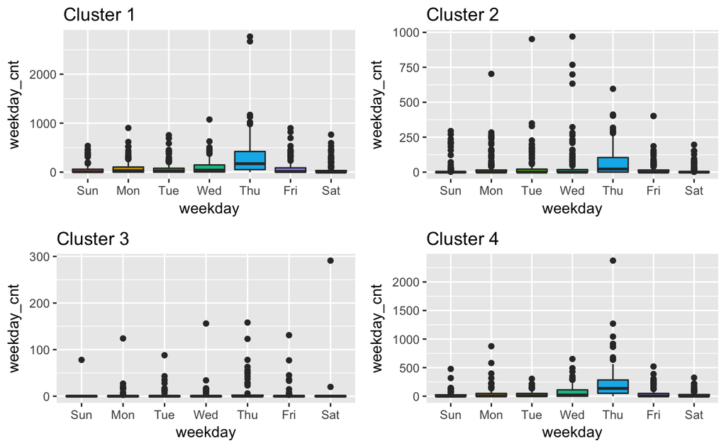

```r
boxplot.weekday.counts(video_wd_long)
```

### Comparison based on the use of Multiple Choice Questions (MCQs)

Compute MCQ-related events for each day of a week

```r
## from daily.res.counts select only variables related to MCQ counts
mcq.vars <- count.vars[grep(".+_MCQ", count.vars)]
mcq.vars <- c('user_id', mcq.vars)
mcq.counts <- daily.res.counts %>% select(one_of(mcq.vars))
mcq.counts <- merge(x = mcq.counts, y = cluster.assignments %>% select(user_id, cl4),
                      by = 'user_id', all.x = F, all.y = T)
mcq.wd.counts <- weekday.res.counts(mcq.counts)
mcq.wd_long <- gather(mcq.wd.counts, weekday, weekday_cnt, Sun:Sat, factor_key=TRUE)
#str(mcq.wd_long)
```

Use boxplots to compare clusters w.r.t. MCQ use per weekday

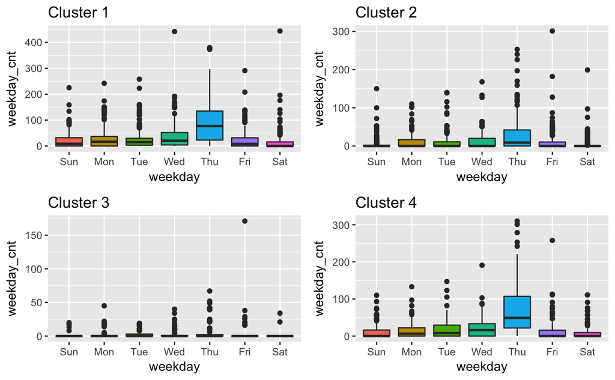

```r
boxplot.weekday.counts(mcq.wd_long)
```

### Comparison based on the use of exercises

Compute exercise-related events for each day of a week

```r
## from daily.res.counts select only variables related to EXE counts
exe.vars <- count.vars[grep(".+_EXE", count.vars)]
exe.vars <- c('user_id', exe.vars)
exe.counts <- daily.res.counts %>% select(one_of(exe.vars))
exe.counts <- merge(x = exe.counts, y = cluster.assignments %>% select(user_id, cl4),
                      by = 'user_id', all.x = F, all.y = T)
exe.wd.counts <- weekday.res.counts(exe.counts)
exe.wd_long <- gather(exe.wd.counts, weekday, weekday_cnt, Sun:Sat, factor_key=TRUE)
#str(exe.wd_long)
```

Use boxplots to compare clusters w.r.t. exercise use per weekday

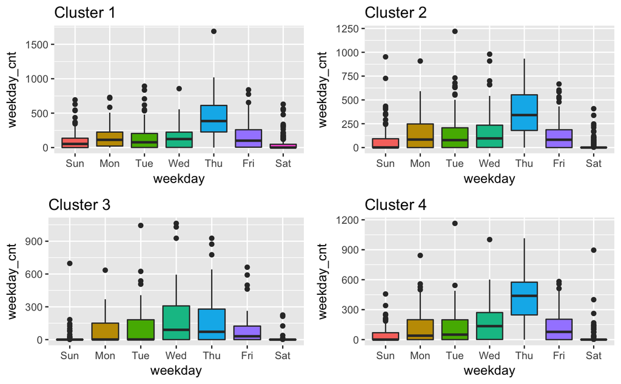

```r
boxplot.weekday.counts(exe.wd_long)
```

### Comparison based on the use of metacognitive items (dashboard, studykit, ‘XY-panel’)

Compute metacognitive events for each day of a week

```r
## from daily.res.counts select only variables related to METACOG counts
mcog.vars <- count.vars[grep(".+_METACOG", count.vars)]
mcog.vars <- c('user_id', mcog.vars)
mcog.counts <- daily.res.counts %>% select(one_of(mcog.vars))
mcog.counts <- merge(x = mcog.counts, y = cluster.assignments %>% select(user_id, cl4),
                      by = 'user_id', all.x = F, all.y = T)
mcog.wd.counts <- weekday.res.counts(mcog.counts)
mcog.wd_long <- gather(mcog.wd.counts, weekday, weekday_cnt, Sun:Sat, factor_key=TRUE)
str(mcog.wd_long)
```

```
'data.frame':   3339 obs. of  4 variables:
 $ user_id    : num  679 680 681 682 683 688 689 691 693 694 ...
 $ cl         : num  1 1 2 2 2 3 3 4 4 4 ...
 $ weekday    : Factor w/ 7 levels "Sun","Mon","Tue",..: 1 1 1 1 1 1 1 1 1 1 ...
 $ weekday_cnt: num  0 0 0 0 0 0 0 7 0 2 ...
```

Draw boxplots

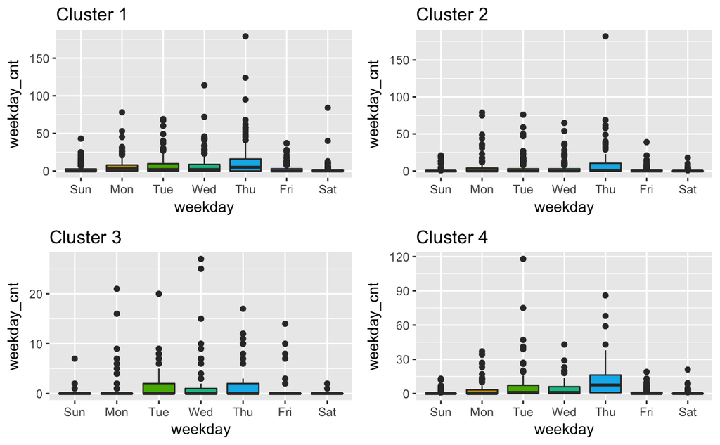

```r
boxplot.weekday.counts(mcog.wd_long)
```

# Cluster comparison w.r.t. the daily topic focus

Comparison of student clusters based on some basic statistics about the different kinds of topics student actions were associtated with during their active days (an active day is a day when a student had at least one study session). The following topic foci were considered:

- ‘ontopic’ - the topic associated with a learning action is the topic of the current week
- ‘revisiting’ - the topic associated with a learning action is the topic of one of the previous weeks
- ‘metacognitive’ - the topic associated with an action is one of the following: ‘ORG’, ‘DBOARD’, ‘STRAT’, ‘STUDYKIT’
- ‘orientiring’ - the topic associated with an action is one of the following: ‘HOME’, ‘HOF’, ‘SEARCH’, ‘TEA’, ‘EXAM’, ‘W01’-‘W13’
- ‘project’ - a learning action is related to project work

For each student and each day during weeks 2-5 and 7-12, counts of learning events / actions with the above given topic foci were calculated. So, for each student and each day, we have the number of learning actions that were ‘ontopic’, number of actions that were ‘revisiting’ and so on.

The computed statistics:

- median_X_cnt - median number of learning actions associated with topic X during the student’s active days (X can be ‘ontopic’, ‘revisit’, ‘metacog’, ‘orient’, ‘prj’)
- mad_X_cnt - MAD (median absolute deviation) of the number of learning actions associated with topic X during the student’s active days
- X_days - number of days with at least one learning action associated with topic X
- X_prop - proportion of days with at least one action on topic X versus total number of the student’s active days

Load the topic count stats and merge with the cluster assignments:

```r
topic.stats <- read.csv("Intermediate_results/regularity_of_study/topic_counts_statistics_w2-5_7-12.csv")
topic.stats <- merge(x = topic.stats, y = cluster.assignments %>% select(user_id, cl4),
                       by = 'user_id', all.x = F, all.y = T)
```

Compute cluster-level summary statistics for the topic statistics

```r
clust.topic.stats <- summary.stats(topic.stats %>% select(-c(user_id, cl4)),
                                     topic.stats$cl4, 4)
kable(x = clust.topic.stats)
```

| attributes | Median; (Q1, Q3) | Median; (Q1, Q3) | Median; (Q1, Q3) | Median; (Q1, Q3) |
| --- | --- | --- | --- | --- |
| cluster | 1 | 2 | 3 | 4 |
| freq | 170 | 155 | 56 | 96 |
| median_ontopic_cnt | 3; (0, 7.88) | 2; (0, 11.75) | 2; (0, 18.25) | 1; (0, 5.62) |
| mad_ontopic_cnt | 4.45; (0, 11.68) | 2.97; (0, 17.42) | 2.22; (0, 20.76) | 1.48; (0, 8.34) |
| ontopic_days | 22; (18, 27.75) | 13; (11, 17) | 7; (4.75, 10) | 16; (13, 20) |
| ontopic_prop | 0.56; (0.48, 0.65) | 0.53; (0.44, 0.63) | 0.53; (0.35, 0.67) | 0.5; (0.44, 0.59) |
| median_revisit_cnt | 0; (0, 0) | 0; (0, 0) | 0; (0, 4) | 0; (0, 1) |
| mad_revisit_cnt | 0; (0, 0) | 0; (0, 0) | 0; (0, 4.82) | 0; (0, 1.48) |
| revisit_days | 16; (12, 19) | 10; (8, 12) | 6; (4, 8) | 14; (11, 17) |
| revisit_prop | 0.39; (0.3, 0.49) | 0.4; (0.3, 0.48) | 0.4; (0.29, 0.56) | 0.43; (0.33, 0.53) |
| median_metacog_cnt | 5; (4, 8) | 4; (3, 6) | 5; (3, 6.62) | 5.5; (4, 7) |
| mad_metacog_cnt | 4.45; (2.97, 7.41) | 3.71; (2.97, 5.93) | 2.97; (2.04, 4.45) | 5.19; (3.71, 6.67) |
| metacog_days | 38; (35, 42) | 25; (22, 27) | 15.5; (11, 18.25) | 31; (29, 34) |
| metacog_prop | 0.97; (0.94, 1) | 1; (0.95, 1) | 1; (1, 1) | 0.97; (0.95, 1) |
| median_orient_cnt | 5.5; (4, 7.88) | 4; (3, 6) | 4; (3, 5.62) | 6; (4.88, 7) |
| mad_orient_cnt | 4.45; (3.71, 7.41) | 3.71; (2.97, 5.56) | 2.97; (1.48, 4.45) | 4.82; (3.71, 5.93) |
| orinet_days | 39; (36, 43) | 25; (22, 28) | 16; (11, 19) | 32; (29, 34) |
| orient_prop | 0.98; (0.97, 1) | 1; (0.96, 1) | 1; (1, 1) | 1; (0.97, 1) |
| median_prj_cnt | 0; (0, 0) | 0; (0, 0) | 0; (0, 0) | 0; (0, 0) |
| mad_prj_cnt | 0; (0, 0) | 0; (0, 0) | 0; (0, 0) | 0; (0, 0) |
| prj_days | 8.5; (7, 11) | 5; (4, 7) | 2.5; (1, 5) | 7; (5, 9) |
| prj_prop | 0.21; (0.18, 0.26) | 0.21; (0.16, 0.27) | 0.18; (0.08, 0.29) | 0.23; (0.17, 0.27) |

Check if there is a stat. significant difference among the clusters w.r.t. the topic statistics

```r
apply(topic.stats %>% select(-c(user_id, cl4)),
      2, function(x) kruskal.test(x ~ topic.stats$cl4))
```

```
$median_ontopic_cnt

    Kruskal-Wallis rank sum test

data:  x by topic.stats$cl4
Kruskal-Wallis chi-squared = 5.0119, df = 3, p-value = 0.1709


$mad_ontopic_cnt

    Kruskal-Wallis rank sum test

data:  x by topic.stats$cl4
Kruskal-Wallis chi-squared = 3.7712, df = 3, p-value = 0.2872


$ontopic_days

    Kruskal-Wallis rank sum test

data:  x by topic.stats$cl4
Kruskal-Wallis chi-squared = 234.88, df = 3, p-value < 2.2e-16


$ontopic_prop

    Kruskal-Wallis rank sum test

data:  x by topic.stats$cl4
Kruskal-Wallis chi-squared = 9.9683, df = 3, p-value = 0.01884


$median_revisit_cnt

    Kruskal-Wallis rank sum test

data:  x by topic.stats$cl4
Kruskal-Wallis chi-squared = 14.433, df = 3, p-value = 0.002371


```

[output cut: 103 more lines]

```

$prj_days

    Kruskal-Wallis rank sum test

data:  x by topic.stats$cl4
Kruskal-Wallis chi-squared = 168.83, df = 3, p-value < 2.2e-16


$prj_prop

    Kruskal-Wallis rank sum test

data:  x by topic.stats$cl4
Kruskal-Wallis chi-squared = 6.1624, df = 3, p-value = 0.104
```

Stat. significant difference among the clusters is present for the following variables:

- X_days
- ontopic_prop
- median_revisit_cnt
- mad_revisit_cnt
- median_metacog_cnt
- mad_metacog_cnt
- metacog_prop
- median_orient_cnt
- mad_orient_cnt
- orient_prop

note: p values for median_prj_cnt and mad_prj_cnt are close to the set alpha value (0.05), so, at most one pair of clusters could be significantly different w.r.t. these variables

### Pair-wise comparisons of clusters with Mann-Whitney U Test

#### Comparison based on the *ontopic_days* variable

```r
ontopic_days_compare <- pairwise.compare.clusters(topic.stats$ontopic_days,
                                                     topic.stats$cl4, 6)
kable(ontopic_days_compare)
```

|  | c1 | c2 | Z | p | r | significant | alpha |
| --- | --- | --- | --- | --- | --- | --- | --- |
| 1 | 1 | 2 | 11.6693 | 0.0e+00 | 0.6473 | YES | 0.0083333 |
| 2 | 1 | 3 | 10.9495 | 0.0e+00 | 0.7283 | YES | 0.0166667 |
| 3 | 1 | 4 | 7.7558 | 0.0e+00 | 0.4755 | YES | 0.0250000 |
| 4 | 2 | 3 | 7.4760 | 0.0e+00 | 0.5147 | YES | 0.0333333 |
| 6 | 3 | 4 | -8.7524 | 0.0e+00 | 0.7099 | YES | 0.0416667 |
| 5 | 2 | 4 | -4.2376 | 1.9e-05 | 0.2675 | YES | 0.0500000 |

All cluster pairs are significantly different w.r.t. the *ontopic_days* variable

#### Comparison based on the *revisit_days* variable

```r
revisit_days_compare <- pairwise.compare.clusters(topic.stats$revisit_days,
                                                     topic.stats$cl4, 6)
kable(revisit_days_compare)
```

|  | c1 | c2 | Z | p | r | significant | alpha |
| --- | --- | --- | --- | --- | --- | --- | --- |
| 1 | 1 | 2 | 9.3365 | 0.000000 | 0.5179 | YES | 0.0083333 |
| 2 | 1 | 3 | 9.2508 | 0.000000 | 0.6154 | YES | 0.0166667 |
| 4 | 2 | 3 | 6.2185 | 0.000000 | 0.4281 | YES | 0.0250000 |
| 5 | 2 | 4 | -6.7550 | 0.000000 | 0.4264 | YES | 0.0333333 |
| 6 | 3 | 4 | -8.0951 | 0.000000 | 0.6566 | YES | 0.0416667 |
| 3 | 1 | 4 | 2.5136 | 0.011785 | 0.1541 | YES | 0.0500000 |

All cluster pairs are significantly different w.r.t. the *revisit_days* variable

#### Comparison based on the *metacog_days* variable

```r
metacog_days_compare <- pairwise.compare.clusters(topic.stats$metacog_days,
                                                     topic.stats$cl4, 6)
kable(metacog_days_compare)
```

| c1 | c2 | Z | p | r | significant | alpha |
| --- | --- | --- | --- | --- | --- | --- |
| 1 | 2 | 15.2755 | 0 | 0.8473 | YES | 0.0083333 |
| 1 | 3 | 11.2269 | 0 | 0.7468 | YES | 0.0166667 |
| 1 | 4 | 10.3761 | 0 | 0.6362 | YES | 0.0250000 |
| 2 | 3 | 10.1119 | 0 | 0.6961 | YES | 0.0333333 |
| 2 | 4 | -9.7930 | 0 | 0.6181 | YES | 0.0416667 |
| 3 | 4 | -10.2542 | 0 | 0.8317 | YES | 0.0500000 |

All cluster pairs are significantly different w.r.t. the *metacog_days* variable

#### Comparison based on the *prj_days* variable

```r
proj_days_compare <- pairwise.compare.clusters(topic.stats$prj_days,
                                                     topic.stats$cl4, 6)
kable(proj_days_compare)
```

|  | c1 | c2 | Z | p | r | significant | alpha |
| --- | --- | --- | --- | --- | --- | --- | --- |
| 1 | 1 | 2 | 9.7958 | 0.0e+00 | 0.5434 | YES | 0.0083333 |
| 2 | 1 | 3 | 10.0116 | 0.0e+00 | 0.6660 | YES | 0.0166667 |
| 4 | 2 | 3 | 6.0658 | 0.0e+00 | 0.4176 | YES | 0.0250000 |
| 6 | 3 | 4 | -7.8826 | 0.0e+00 | 0.6394 | YES | 0.0333333 |
| 5 | 2 | 4 | -4.8375 | 1.0e-06 | 0.3053 | YES | 0.0416667 |
| 3 | 1 | 4 | 4.1538 | 2.8e-05 | 0.2547 | YES | 0.0500000 |

All cluster pairs are significantly different w.r.t. the *prj_days* variable

#### Comparison based on the *orient_days* variable

```r
ornt_days_compare <- pairwise.compare.clusters(topic.stats$orinet_days,
                                                     topic.stats$cl4, 6)
kable(ornt_days_compare)
```

| c1 | c2 | Z | p | r | significant | alpha |
| --- | --- | --- | --- | --- | --- | --- |
| 1 | 2 | 15.3463 | 0 | 0.8513 | YES | 0.0083333 |
| 1 | 3 | 11.2265 | 0 | 0.7468 | YES | 0.0166667 |
| 1 | 4 | 10.6410 | 0 | 0.6524 | YES | 0.0250000 |
| 2 | 3 | 10.0830 | 0 | 0.6941 | YES | 0.0333333 |
| 2 | 4 | -10.0777 | 0 | 0.6361 | YES | 0.0416667 |
| 3 | 4 | -10.2657 | 0 | 0.8327 | YES | 0.0500000 |

All cluster pairs are significantly different w.r.t. the *orient_days* variable

#### Comparison based on the *ontopic_prop* variable

```r
ontopic_prop_compare <- pairwise.compare.clusters(topic.stats$ontopic_prop,
                                                     topic.stats$cl4, 6)
kable(ontopic_prop_compare)
```

|  | c1 | c2 | Z | p | r | significant | alpha |
| --- | --- | --- | --- | --- | --- | --- | --- |
| 3 | 1 | 4 | 3.2198 | 0.001218 | 0.1974 | YES | 0.0083333 |
| 1 | 1 | 2 | 1.7819 | 0.074785 | 0.0988 | NO | 0.0166667 |
| 2 | 1 | 3 | 1.4399 | 0.150432 | 0.0958 | NO | 0.0250000 |
| 5 | 2 | 4 | 1.3707 | 0.170922 | 0.0865 | NO | 0.0333333 |
| 4 | 2 | 3 | 0.5236 | 0.601972 | 0.0360 | NO | 0.0416667 |
| 6 | 3 | 4 | 0.3152 | 0.754079 | 0.0256 | NO | 0.0500000 |

Only cluster pair 1-4 significantly differs w.r.t. the *ontopic_prop* variable.

#### Comparison based on the *median_revisit_cnt* variable

```r
median_rev_cnt_compare <- pairwise.compare.clusters(topic.stats$median_revisit_cnt,
                                                     topic.stats$cl4, 6)
kable(median_rev_cnt_compare)
```

|  | c1 | c2 | Z | p | r | significant | alpha |
| --- | --- | --- | --- | --- | --- | --- | --- |
| 2 | 1 | 3 | -2.7905 | 0.005015 | 0.1856 | YES | 0.0083333 |
| 3 | 1 | 4 | -2.7202 | 0.006351 | 0.1668 | YES | 0.0166667 |
| 4 | 2 | 3 | -2.5960 | 0.009110 | 0.1787 | YES | 0.0250000 |
| 5 | 2 | 4 | -2.5544 | 0.010435 | 0.1612 | YES | 0.0333333 |
| 6 | 3 | 4 | 0.7749 | 0.440249 | 0.0629 | NO | 0.0416667 |
| 1 | 1 | 2 | -0.1586 | 0.874601 | 0.0088 | NO | 0.0500000 |

Except for the cluster pairs 1-2 and 3-4, all other cluster pairs are significantly different w.r.t. the *median_revisit_cnt* variable.

#### Comparison based on the *mad_revisit_cnt* variable

```r
mad_rev_cnt_compare <- pairwise.compare.clusters(topic.stats$mad_revisit_cnt,
                                                     topic.stats$cl4, 6)
kable(mad_rev_cnt_compare)
```

|  | c1 | c2 | Z | p | r | significant | alpha |
| --- | --- | --- | --- | --- | --- | --- | --- |
| 2 | 1 | 3 | -2.7708 | 0.005345 | 0.1843 | YES | 0.0083333 |
| 3 | 1 | 4 | -2.7171 | 0.006412 | 0.1666 | YES | 0.0166667 |
| 4 | 2 | 3 | -2.5798 | 0.009568 | 0.1776 | YES | 0.0250000 |
| 5 | 2 | 4 | -2.5478 | 0.010638 | 0.1608 | YES | 0.0333333 |
| 6 | 3 | 4 | 0.7662 | 0.445412 | 0.0621 | NO | 0.0416667 |
| 1 | 1 | 2 | -0.1586 | 0.874601 | 0.0088 | NO | 0.0500000 |

Except for the cluster pairs 1-2 and 3-4, all other cluster pairs are significantly different w.r.t. the *mad_revisit_cnt* variable.

#### Comparison based on the *median_metacog_cnt* variable

```r
median_mcog_cnt_compare <- pairwise.compare.clusters(topic.stats$median_metacog_cnt,
                                                     topic.stats$cl4, 6)
kable(median_mcog_cnt_compare)
```

|  | c1 | c2 | Z | p | r | significant | alpha |
| --- | --- | --- | --- | --- | --- | --- | --- |
| 1 | 1 | 2 | 3.8286 | 0.000118 | 0.2124 | YES | 0.0083333 |
| 5 | 2 | 4 | -3.3900 | 0.000653 | 0.2140 | YES | 0.0166667 |
| 2 | 1 | 3 | 1.7863 | 0.074096 | 0.1188 | NO | 0.0250000 |
| 6 | 3 | 4 | -1.7189 | 0.085830 | 0.1394 | NO | 0.0333333 |
| 4 | 2 | 3 | -0.6862 | 0.494059 | 0.0472 | NO | 0.0416667 |
| 3 | 1 | 4 | 0.1301 | 0.896984 | 0.0080 | NO | 0.0500000 |

Only cluster pairs 1-2 and 2-4 are significantly different w.r.t. the *median_metacog_cnt* variable.

#### Comparison based on the *mad_metacog_cnt* variable

```r
mad_mcog_cnt_compare <- pairwise.compare.clusters(topic.stats$mad_metacog_cnt,
                                                     topic.stats$cl4, 6)
kable(mad_mcog_cnt_compare)
```

|  | c1 | c2 | Z | p | r | significant | alpha |
| --- | --- | --- | --- | --- | --- | --- | --- |
| 2 | 1 | 3 | 4.4992 | 0.000005 | 0.2993 | YES | 0.0083333 |
| 6 | 3 | 4 | -4.1800 | 0.000021 | 0.3390 | YES | 0.0166667 |
| 1 | 1 | 2 | 4.0185 | 0.000053 | 0.2229 | YES | 0.0250000 |
| 5 | 2 | 4 | -3.2898 | 0.000945 | 0.2077 | YES | 0.0333333 |
| 4 | 2 | 3 | 1.9887 | 0.046599 | 0.1369 | NO | 0.0416667 |
| 3 | 1 | 4 | 0.4829 | 0.630060 | 0.0296 | NO | 0.0500000 |

Except for cluster pairs 1-4 and 2-3, all other cluster pairs are significantly different w.r.t. the *mad_metacog_cnt* variable.

#### Comparison based on the *metacog_prop* variable

```r
mcog_prop_compare <- pairwise.compare.clusters(topic.stats$metacog_prop,
                                                     topic.stats$cl4, 6)
kable(mcog_prop_compare)
```

|  | c1 | c2 | Z | p | r | significant | alpha |
| --- | --- | --- | --- | --- | --- | --- | --- |
| 2 | 1 | 3 | -5.1811 | 0.000000 | 0.3446 | YES | 0.0083333 |
| 6 | 3 | 4 | 3.5783 | 0.000303 | 0.2902 | YES | 0.0166667 |
| 1 | 1 | 2 | -2.9830 | 0.002792 | 0.1655 | YES | 0.0250000 |
| 4 | 2 | 3 | -2.9105 | 0.003439 | 0.2004 | YES | 0.0333333 |
| 3 | 1 | 4 | -1.5785 | 0.114663 | 0.0968 | NO | 0.0416667 |
| 5 | 2 | 4 | 0.5889 | 0.556883 | 0.0372 | NO | 0.0500000 |

Except for cluster pairs 1-4 and 2-4, all other cluster pairs are significantly different w.r.t. the *metacog_prop* variable.

#### Comparison based on the *median_orient_cnt* variable

```r
median_ornt_cnt_compare <- pairwise.compare.clusters(topic.stats$median_orient_cnt,
                                                     topic.stats$cl4, 6)
kable(median_ornt_cnt_compare)
```

|  | c1 | c2 | Z | p | r | significant | alpha |
| --- | --- | --- | --- | --- | --- | --- | --- |
| 1 | 1 | 2 | 4.9021 | 0.000001 | 0.2719 | YES | 0.0083333 |
| 5 | 2 | 4 | -4.5676 | 0.000004 | 0.2883 | YES | 0.0166667 |
| 6 | 3 | 4 | -3.7127 | 0.000171 | 0.3011 | YES | 0.0250000 |
| 2 | 1 | 3 | 3.7023 | 0.000183 | 0.2463 | YES | 0.0333333 |
| 4 | 2 | 3 | 0.6134 | 0.541077 | 0.0422 | NO | 0.0416667 |
| 3 | 1 | 4 | -0.3223 | 0.747985 | 0.0198 | NO | 0.0500000 |

Except for cluster pairs 1-4 and 2-3, all other cluster pairs are significantly different w.r.t. the *median_orient_cnt* variable.

#### Comparison based on the *mad_orient_cnt* variable

```r
mad_ornt_cnt_compare <- pairwise.compare.clusters(topic.stats$mad_orient_cnt,
                                                     topic.stats$cl4, 6)
kable(mad_ornt_cnt_compare)
```

|  | c1 | c2 | Z | p | r | significant | alpha |
| --- | --- | --- | --- | --- | --- | --- | --- |
| 2 | 1 | 3 | 5.6423 | 0.000000 | 0.3753 | YES | 0.0083333 |
| 6 | 3 | 4 | -5.1526 | 0.000000 | 0.4179 | YES | 0.0166667 |
| 1 | 1 | 2 | 4.5602 | 0.000004 | 0.2530 | YES | 0.0250000 |
| 5 | 2 | 4 | -3.9418 | 0.000071 | 0.2488 | YES | 0.0333333 |
| 4 | 2 | 3 | 2.6566 | 0.007657 | 0.1829 | YES | 0.0416667 |
| 3 | 1 | 4 | -0.0252 | 0.980277 | 0.0015 | NO | 0.0500000 |

Except for cluster pair 1-4, all other cluster pairs are significantly different w.r.t. the *mad_orient_cnt* variable.

#### Comparison based on the *orient_prop* variable

```r
ornt_prop_compare <- pairwise.compare.clusters(topic.stats$orient_prop,
                                                     topic.stats$cl4, 6)
kable(ornt_prop_compare)
```

|  | c1 | c2 | Z | p | r | significant | alpha |
| --- | --- | --- | --- | --- | --- | --- | --- |
| 2 | 1 | 3 | -5.2389 | 0.000000 | 0.3485 | YES | 0.0083333 |
| 6 | 3 | 4 | 4.1380 | 0.000027 | 0.3356 | YES | 0.0166667 |
| 4 | 2 | 3 | -3.3476 | 0.000758 | 0.2305 | YES | 0.0250000 |
| 1 | 1 | 2 | -2.2456 | 0.024627 | 0.1246 | YES | 0.0333333 |
| 3 | 1 | 4 | -0.7707 | 0.441766 | 0.0473 | NO | 0.0416667 |
| 5 | 2 | 4 | 0.5616 | 0.575470 | 0.0354 | NO | 0.0500000 |

Except for cluster pairs 1-4 and 2-4, all other cluster pairs are significantly different w.r.t. the *orient_prop* variable.